# Machine Learning

**Steps of Machine Learning**

1. Problem definition
2. Data collection
3. Evaluation (What defines success?)
4. Features (What features can we use?)
5. Modelling (What model to use?)
6. Experimentation (How can we improve?)

**Overfitting and Underfitting Definitions**

- **Underfitting**: Poor performance on training data means the model hasn't learned properly and is underfitting. Try a different model, improve the existing one through hyperparameter or collect more data.
- **Overfitting**: Great performance on the training data but poor performance on test data means your model doesn't generalize well. Your model may be overfitting the training data. Try using a simpler model or making sure the test data is of the same style your model is training on.

## Data Science Recap

### Pandas - Data Analysis

- Simple to use
- Integrated with amy other data science and ML Python Tools
- Helps you get your data ready for machine learning

#### Series, Data Frames and CSVs

```python
import pandas as pd
```

```python
# 2 main datatypes
series = pd.Series(["BMW", "Toyota", "Honda"])
series

#series = 1-dimensional
```

```
0       BMW
1    Toyota
2     Honda
dtype: object
```

```python
colors = pd.Series(["Red", "Blue", "White"])
colors
```

```
0      Red
1     Blue
2    White
dtype: object
```

- The difference between Series and Data Frames is that a Series is a single column of data while a DataFrame is multiple columns of data.

```python
car_data = pd.DataFrame({"Car make": series, "Color": colors})
car_data
```

|  | Car make | Color |
| --- | --- | --- |
| 0 | BMW | Red |
| 1 | Toyota | Blue |
| 2 | Honda | White |

```python
# Import data
car_sales = pd.read_csv("data/car-sales.csv")
car_sales.head()
```

|  | Make | Colour | Odometer (KM) | Doors | Price |
| --- | --- | --- | --- | --- | --- |
| 0 | Toyota | White | 150043 | 4 | $4,000.00 |
| 1 | Honda | Red | 87899 | 4 | $5,000.00 |
| 2 | Toyota | Blue | 32549 | 3 | $7,000.00 |
| 3 | BMW | Black | 11179 | 5 | $22,000.00 |
| 4 | Nissan | White | 213095 | 4 | $3,500.00 |

- **Anatomy of a DataFrame**: A DataFrame is a two-dimensional data structure where the data is aligned in a tabular fashion in rows and columns.
- `axis=0` refers to rows and `axis=1` refers to columns.
- Indexes are the default row numbers in a DataFrame. It always starts at 0.

```python
#Exporting data frame
car_sales.to_csv('data/exported-car-sales.csv', index=False) #if we don't add index = False, it will add an extra column with the index numbers
```

```python
exported_car_sales = pd.read_csv('data/exported-car-sales.csv')
exported_car_sales
```

|  | Make | Colour | Odometer (KM) | Doors | Price |
| --- | --- | --- | --- | --- | --- |
| 0 | Toyota | White | 150043 | 4 | $4,000.00 |
| 1 | Honda | Red | 87899 | 4 | $5,000.00 |
| 2 | Toyota | Blue | 32549 | 3 | $7,000.00 |
| 3 | BMW | Black | 11179 | 5 | $22,000.00 |
| 4 | Nissan | White | 213095 | 4 | $3,500.00 |
| 5 | Toyota | Green | 99213 | 4 | $4,500.00 |
| 6 | Honda | Blue | 45698 | 4 | $7,500.00 |
| 7 | Honda | Blue | 54738 | 4 | $7,000.00 |
| 8 | Toyota | White | 60000 | 4 | $6,250.00 |
| 9 | Nissan | White | 31600 | 4 | $9,700.00 |

#### Describe Data

```python
car_sales.dtypes
```

```
Make             object
Colour           object
Odometer (KM)     int64
Doors             int64
Price            object
dtype: object
```

- Quick note: The main difference between an attribute (which `dtypes` is) and a function is that an attribute is a description of a data structure while a function is an action we can perform.

```python
car_sales.columns
#we can save this attribute as a variable, and then we can use it to access the columns

car_sales_columns = car_sales.columns
car_sales_columns #after changing it to a list, we can manipulate the data
```

```
Index(['Make', 'Colour', 'Odometer (KM)', 'Doors', 'Price'], dtype='object')
```

```python
car_sales.index #shows the range of the index (rows)
```

```
RangeIndex(start=0, stop=10, step=1)
```

```python
car_sales.describe() #shows the statistics of the numerical columns
#here sales does not come out, because it is not a numerical column, it is an object
```

|  | Odometer (KM) | Doors |
| --- | --- | --- |
| count | 10.000000 | 10.000000 |
| mean | 78601.400000 | 4.000000 |
| std | 61983.471735 | 0.471405 |
| min | 11179.000000 | 3.000000 |
| 25% | 35836.250000 | 4.000000 |
| 50% | 57369.000000 | 4.000000 |
| 75% | 96384.500000 | 4.000000 |
| max | 213095.000000 | 5.000000 |

```python
car_sales.info() #shows the data types and the non-null values
```

```
<class 'pandas.core.frame.DataFrame'>
RangeIndex: 10 entries, 0 to 9
Data columns (total 5 columns):
 #   Column         Non-Null Count  Dtype
---  ------         --------------  -----
 0   Make           10 non-null     object
 1   Colour         10 non-null     object
 2   Odometer (KM)  10 non-null     int64
 3   Doors          10 non-null     int64
 4   Price          10 non-null     object
dtypes: int64(2), object(3)
memory usage: 532.0+ bytes
```

```python
#car_sales.select_dtypes(include='number').mean() #shows the mean of the numerical columns
car_sales.mean(numeric_only=True) #same as above
```

```
Odometer (KM)    78601.4
Doors                4.0
dtype: float64
```

```python
car_sales["Doors"].sum()
```

```
np.int64(40)
```

```python
car_sales["Price"].sum()
```

```
'$4,000.00$5,000.00$7,000.00$22,000.00$3,500.00$4,500.00$7,500.00$7,000.00$6,250.00$9,700.00'
```

#### Viewing and Selecting Data

```python
car_sales.head() #shows the first 5 rows
```

|  | Make | Colour | Odometer (KM) | Doors | Price |
| --- | --- | --- | --- | --- | --- |
| 0 | Toyota | White | 150043 | 4 | $4,000.00 |
| 1 | Honda | Red | 87899 | 4 | $5,000.00 |
| 2 | Toyota | Blue | 32549 | 3 | $7,000.00 |
| 3 | BMW | Black | 11179 | 5 | $22,000.00 |
| 4 | Nissan | White | 213095 | 4 | $3,500.00 |

```python
car_sales.tail() #shows the last 5 rows
```

|  | Make | Colour | Odometer (KM) | Doors | Price |
| --- | --- | --- | --- | --- | --- |
| 5 | Toyota | Green | 99213 | 4 | $4,500.00 |
| 6 | Honda | Blue | 45698 | 4 | $7,500.00 |
| 7 | Honda | Blue | 54738 | 4 | $7,000.00 |
| 8 | Toyota | White | 60000 | 4 | $6,250.00 |
| 9 | Nissan | White | 31600 | 4 | $9,700.00 |

```python
# .loc and .iloc
animals = pd.Series(["cat", "dog", "bird", "panda", "snake"],
                    index=[0, 3, 9, 8, 3])
```

```python
#.loc
animals
```

```
0      cat
3      dog
9     bird
8    panda
3    snake
dtype: object
```

```python
animals.loc[3] #loc refers to the index
```

```
3      dog
3    snake
dtype: object
```

```python
animals.loc[9]
```

```
'bird'
```

```python
car_sales.loc[6]
```

```
Make                 Honda
Colour                Blue
Odometer (KM)        45698
Doors                    4
Price            $7,500.00
Name: 6, dtype: object
```

```python
#.iloc refers to the position
animals.iloc[3] #iloc refers to the position
```

```
'panda'
```

```python
car_sales.iloc[3]
```

```
Make                    BMW
Colour                Black
Odometer (KM)         11179
Doors                     5
Price            $22,000.00
Name: 3, dtype: object
```

```python
#slicing
animals.iloc[:3] #.iloc does not include the last number
```

```
0     cat
3     dog
9    bird
dtype: object
```

```python
car_sales.loc[:3] #.loc includes the last number
```

|  | Make | Colour | Odometer (KM) | Doors | Price |
| --- | --- | --- | --- | --- | --- |
| 0 | Toyota | White | 150043 | 4 | $4,000.00 |
| 1 | Honda | Red | 87899 | 4 | $5,000.00 |
| 2 | Toyota | Blue | 32549 | 3 | $7,000.00 |
| 3 | BMW | Black | 11179 | 5 | $22,000.00 |

```python
car_sales["Make"]
```

```
0    Toyota
1     Honda
2    Toyota
3       BMW
4    Nissan
5    Toyota
6     Honda
7     Honda
8    Toyota
9    Nissan
Name: Make, dtype: object
```

```python
car_sales.Make #this is the same as above
## But if you column name has a space, you can't use the dot notation
```

```
0    Toyota
1     Honda
2    Toyota
3       BMW
4    Nissan
5    Toyota
6     Honda
7     Honda
8    Toyota
9    Nissan
Name: Make, dtype: object
```

```python
car_sales[car_sales["Make"] == "Toyota"] #shows the rows where the make is Toyota
```

|  | Make | Colour | Odometer (KM) | Doors | Price |
| --- | --- | --- | --- | --- | --- |
| 0 | Toyota | White | 150043 | 4 | $4,000.00 |
| 2 | Toyota | Blue | 32549 | 3 | $7,000.00 |
| 5 | Toyota | Green | 99213 | 4 | $4,500.00 |
| 8 | Toyota | White | 60000 | 4 | $6,250.00 |

```python
pd.crosstab(car_sales["Make"], car_sales["Doors"]) #shows the frequency of the make and the doors
```

| Doors Make | 3 | 4 | 5 |
| --- | --- | --- | --- |
| BMW | 0 | 0 | 1 |
| Honda | 0 | 3 | 0 |
| Nissan | 0 | 2 | 0 |
| Toyota | 1 | 3 | 0 |

```python
#what if we want to compare more columns in the context of another column
## groupby

car_sales.groupby(["Make"]).mean(numeric_only=True) #shows the mean of the numerical columns, grouped by the make
```

| Make | Odometer (KM) | Doors |
| --- | --- | --- |
| BMW | 11179.000000 | 5.00 |
| Honda | 62778.333333 | 4.00 |
| Nissan | 122347.500000 | 4.00 |
| Toyota | 85451.250000 | 3.75 |

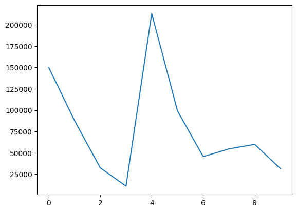

```python
#visualizing data, to get a first glimpse of the data
car_sales["Odometer (KM)"].plot() #shows the plot of the odometer
```

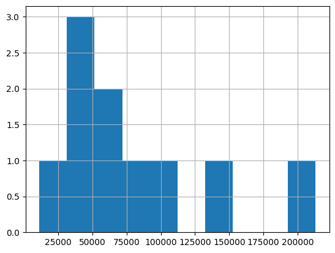

```python
car_sales["Odometer (KM)"].hist() #shows the histogram of the odometer
```

```python
#to plot the price, we need to change the data type
car_sales["Price"].dtype #it is an object
```

```
dtype('O')
```

```python
car_sales["Price"] = car_sales["Price"].str.replace('[\$\,\.]', '', regex=True).astype(int) #this will remove the $ and the , and change the data type to int
```

```python
car_sales
#with the code above, cents are considered, and it is a bit confusing, so we can divide the price by 100
```

|  | Make | Colour | Odometer (KM) | Doors | Price |
| --- | --- | --- | --- | --- | --- |
| 0 | Toyota | White | 150043 | 4 | 400000 |
| 1 | Honda | Red | 87899 | 4 | 500000 |
| 2 | Toyota | Blue | 32549 | 3 | 700000 |
| 3 | BMW | Black | 11179 | 5 | 2200000 |
| 4 | Nissan | White | 213095 | 4 | 350000 |
| 5 | Toyota | Green | 99213 | 4 | 450000 |
| 6 | Honda | Blue | 45698 | 4 | 750000 |
| 7 | Honda | Blue | 54738 | 4 | 700000 |
| 8 | Toyota | White | 60000 | 4 | 625000 |
| 9 | Nissan | White | 31600 | 4 | 970000 |

```python
car_sales["Price"] = car_sales["Price"] / 100
car_sales
```

|  | Make | Colour | Odometer (KM) | Doors | Price |
| --- | --- | --- | --- | --- | --- |
| 0 | Toyota | White | 150043 | 4 | 4000.0 |
| 1 | Honda | Red | 87899 | 4 | 5000.0 |
| 2 | Toyota | Blue | 32549 | 3 | 7000.0 |
| 3 | BMW | Black | 11179 | 5 | 22000.0 |
| 4 | Nissan | White | 213095 | 4 | 3500.0 |
| 5 | Toyota | Green | 99213 | 4 | 4500.0 |
| 6 | Honda | Blue | 45698 | 4 | 7500.0 |
| 7 | Honda | Blue | 54738 | 4 | 7000.0 |
| 8 | Toyota | White | 60000 | 4 | 6250.0 |
| 9 | Nissan | White | 31600 | 4 | 9700.0 |

#### Manipulating Data

```python
car_sales["Make"].str.lower()
#this will change the make to lower case, but it will not change the original data frame
## we need to re-assign it to the original data frame
```

```
0    toyota
1     honda
2    toyota
3       bmw
4    nissan
5    toyota
6     honda
7     honda
8    toyota
9    nissan
Name: Make, dtype: object
```

```python
car_sales["Make"] = car_sales["Make"].str.lower()
```

```python
car_sales
```

|  | Make | Colour | Odometer (KM) | Doors | Price |
| --- | --- | --- | --- | --- | --- |
| 0 | toyota | White | 150043 | 4 | 4000.0 |
| 1 | honda | Red | 87899 | 4 | 5000.0 |
| 2 | toyota | Blue | 32549 | 3 | 7000.0 |
| 3 | bmw | Black | 11179 | 5 | 22000.0 |
| 4 | nissan | White | 213095 | 4 | 3500.0 |
| 5 | toyota | Green | 99213 | 4 | 4500.0 |
| 6 | honda | Blue | 45698 | 4 | 7500.0 |
| 7 | honda | Blue | 54738 | 4 | 7000.0 |
| 8 | toyota | White | 60000 | 4 | 6250.0 |
| 9 | nissan | White | 31600 | 4 | 9700.0 |

```python
#Handling missing data
car_sales_missing = pd.read_csv("data/car-sales-missing-data.csv")
car_sales_missing
```

|  | Make | Colour | Odometer | Doors | Price |
| --- | --- | --- | --- | --- | --- |
| 0 | Toyota | White | 150043.0 | 4.0 | $4,000 |
| 1 | Honda | Red | 87899.0 | 4.0 | $5,000 |
| 2 | Toyota | Blue | NaN | 3.0 | $7,000 |
| 3 | BMW | Black | 11179.0 | 5.0 | $22,000 |
| 4 | Nissan | White | 213095.0 | 4.0 | $3,500 |
| 5 | Toyota | Green | NaN | 4.0 | $4,500 |
| 6 | Honda | NaN | NaN | 4.0 | $7,500 |
| 7 | Honda | Blue | NaN | 4.0 | NaN |
| 8 | Toyota | White | 60000.0 | NaN | NaN |
| 9 | NaN | White | 31600.0 | 4.0 | $9,700 |

```python
#if you do not assign this to a variable, it will not change the original data frame
car_sales_missing["Odometer"].fillna(car_sales_missing["Odometer"].mean(numeric_only=True))
```

```
0    150043.000000
1     87899.000000
2     92302.666667
3     11179.000000
4    213095.000000
5     92302.666667
6     92302.666667
7     92302.666667
8     60000.000000
9     31600.000000
Name: Odometer, dtype: float64
```

```python
car_sales_missing
```

|  | Make | Colour | Odometer | Doors | Price |
| --- | --- | --- | --- | --- | --- |
| 0 | Toyota | White | 150043.0 | 4.0 | $4,000 |
| 1 | Honda | Red | 87899.0 | 4.0 | $5,000 |
| 2 | Toyota | Blue | NaN | 3.0 | $7,000 |
| 3 | BMW | Black | 11179.0 | 5.0 | $22,000 |
| 4 | Nissan | White | 213095.0 | 4.0 | $3,500 |
| 5 | Toyota | Green | NaN | 4.0 | $4,500 |
| 6 | Honda | NaN | NaN | 4.0 | $7,500 |
| 7 | Honda | Blue | NaN | 4.0 | NaN |
| 8 | Toyota | White | 60000.0 | NaN | NaN |
| 9 | NaN | White | 31600.0 | 4.0 | $9,700 |

```python
#since it only took inplace, we need to assign it to the original data frame
car_sales_missing["Odometer"] = car_sales_missing["Odometer"].fillna(car_sales_missing["Odometer"].mean(numeric_only=True))

# or another way is using inplace=True in the function instead of assigning it to the original data frame

#car_sales_missing["Odometer"].fillna(car_sales_missing["Odometer"].mean(numeric_only=True), inplace=True)
```

```python
car_sales_missing
```

|  | Make | Colour | Odometer | Doors | Price |
| --- | --- | --- | --- | --- | --- |
| 0 | Toyota | White | 150043.000000 | 4.0 | $4,000 |
| 1 | Honda | Red | 87899.000000 | 4.0 | $5,000 |
| 2 | Toyota | Blue | 92302.666667 | 3.0 | $7,000 |
| 3 | BMW | Black | 11179.000000 | 5.0 | $22,000 |
| 4 | Nissan | White | 213095.000000 | 4.0 | $3,500 |
| 5 | Toyota | Green | 92302.666667 | 4.0 | $4,500 |
| 6 | Honda | NaN | 92302.666667 | 4.0 | $7,500 |
| 7 | Honda | Blue | 92302.666667 | 4.0 | NaN |
| 8 | Toyota | White | 60000.000000 | NaN | NaN |
| 9 | NaN | White | 31600.000000 | 4.0 | $9,700 |

```python
#we want to drop the rows with missing values
car_sales_missing_dropped = car_sales_missing.dropna()
car_sales_missing_dropped
```

|  | Make | Colour | Odometer | Doors | Price |
| --- | --- | --- | --- | --- | --- |
| 0 | Toyota | White | 150043.000000 | 4.0 | $4,000 |
| 1 | Honda | Red | 87899.000000 | 4.0 | $5,000 |
| 2 | Toyota | Blue | 92302.666667 | 3.0 | $7,000 |
| 3 | BMW | Black | 11179.000000 | 5.0 | $22,000 |
| 4 | Nissan | White | 213095.000000 | 4.0 | $3,500 |
| 5 | Toyota | Green | 92302.666667 | 4.0 | $4,500 |

```python
car_sales_missing_dropped.to_csv("data/car-sales-missing-dropped.csv", index=False)
```

```python
#How do we create data from existing data
# Column from series
seats_column = pd.Series([5, 5, 5, 5, 5])

#New column called seats
car_sales["Seats"] = seats_column
```

```python
car_sales #because our series is 5x5 the rest of the values will be NaN
```

|  | Make | Colour | Odometer (KM) | Doors | Price | Seats |
| --- | --- | --- | --- | --- | --- | --- |
| 0 | toyota | White | 150043 | 4 | 4000.0 | 5.0 |
| 1 | honda | Red | 87899 | 4 | 5000.0 | 5.0 |
| 2 | toyota | Blue | 32549 | 3 | 7000.0 | 5.0 |
| 3 | bmw | Black | 11179 | 5 | 22000.0 | 5.0 |
| 4 | nissan | White | 213095 | 4 | 3500.0 | 5.0 |
| 5 | toyota | Green | 99213 | 4 | 4500.0 | NaN |
| 6 | honda | Blue | 45698 | 4 | 7500.0 | NaN |
| 7 | honda | Blue | 54738 | 4 | 7000.0 | NaN |
| 8 | toyota | White | 60000 | 4 | 6250.0 | NaN |
| 9 | nissan | White | 31600 | 4 | 9700.0 | NaN |

```python
#How do we fill the rest?
car_sales["Seats"].fillna(5, inplace=True)
car_sales
```

|  | Make | Colour | Odometer (KM) | Doors | Price | Seats |
| --- | --- | --- | --- | --- | --- | --- |
| 0 | toyota | White | 150043 | 4 | 4000.0 | 5.0 |
| 1 | honda | Red | 87899 | 4 | 5000.0 | 5.0 |
| 2 | toyota | Blue | 32549 | 3 | 7000.0 | 5.0 |
| 3 | bmw | Black | 11179 | 5 | 22000.0 | 5.0 |
| 4 | nissan | White | 213095 | 4 | 3500.0 | 5.0 |
| 5 | toyota | Green | 99213 | 4 | 4500.0 | 5.0 |
| 6 | honda | Blue | 45698 | 4 | 7500.0 | 5.0 |
| 7 | honda | Blue | 54738 | 4 | 7000.0 | 5.0 |
| 8 | toyota | White | 60000 | 4 | 6250.0 | 5.0 |
| 9 | nissan | White | 31600 | 4 | 9700.0 | 5.0 |

```python
#Column from Python list
fuel_economy = [7.5, 9.2, 5.0, 9.6, 8.7, 4.7, 7.6, 8.7, 3.0, 4.5]
car_sales["Fuel per 100KM"] = fuel_economy
```

```python
#when you are creating a colun from a python list, if the length of the list does not match the length of index of the data frame, it will give an error
```

```python
car_sales ["Total fuel used (L)"] = car_sales["Odometer (KM)"] / 100 * car_sales["Fuel per 100KM"]
car_sales
```

|  | Make | Colour | Odometer (KM) | Doors | Price | Seats | Fuel per 100KM | Total fuel used (L) |
| --- | --- | --- | --- | --- | --- | --- | --- | --- |
| 0 | toyota | White | 150043 | 4 | 4000.0 | 5.0 | 7.5 | 11253.225 |
| 1 | honda | Red | 87899 | 4 | 5000.0 | 5.0 | 9.2 | 8086.708 |
| 2 | toyota | Blue | 32549 | 3 | 7000.0 | 5.0 | 5.0 | 1627.450 |
| 3 | bmw | Black | 11179 | 5 | 22000.0 | 5.0 | 9.6 | 1073.184 |
| 4 | nissan | White | 213095 | 4 | 3500.0 | 5.0 | 8.7 | 18539.265 |
| 5 | toyota | Green | 99213 | 4 | 4500.0 | 5.0 | 4.7 | 4663.011 |
| 6 | honda | Blue | 45698 | 4 | 7500.0 | 5.0 | 7.6 | 3473.048 |
| 7 | honda | Blue | 54738 | 4 | 7000.0 | 5.0 | 8.7 | 4762.206 |
| 8 | toyota | White | 60000 | 4 | 6250.0 | 5.0 | 3.0 | 1800.000 |
| 9 | nissan | White | 31600 | 4 | 9700.0 | 5.0 | 4.5 | 1422.000 |